# Assignment 9 - K-means

Author

Md Shakir Moazzem

# 1 Goal of this assignment

The goal of this assignment is for you to **explore the k-means algorithm** learned in class.

In specific, you will be asked to:  
- Use a different number of k than what we did in class,  
- Validate the results of the new model, and  
- Compare your results with those found in class

# 2 Instructions

You will first need to watch (and code along with) the following k-means video:

- k-means lab: https://youtu.be/GFgMp5tYiMU?si=CI0E-2r-cYZLGVL1 (start from beginning of video, watch till the 01:10)
- The partial script for the video above is in our GitHub repository, 04-classcode, **03-25_multivar_kmeans_partial.qmd**. Move the script mentioned above into the `code` subfolder of your `10_multivar` project

**AFTER watching the video and developing the code in class**, then start working on this HW assignment (instructions below):

- Move this script into the `code` subfolder of your `10_multivar` project
- On this script, fill your name under the `title` section of the YAML
- Go back to the class k-means script, choose a different number of k than what we did in class, and run it.

### 2.0.1 Setup

```r
#install.packages("ggcorrplot")
#install.packages("factoextra")
#install.packages("ggpmisc")

library(tidyverse)
library(ggcorrplot)
library(broom)
library(car)
library(factoextra)
library(ggpmisc)
```

### 2.0.2 Importing data

```r
weather <- read_csv("../data/weather_monthsum.csv")
```

## 2.1 Data warngling

### 2.1.1 Selecting only numerical variables

```r
weather_n <- weather %>%
  dplyr::select(-c(year:strength_gtex))
```

### 2.1.2 Normalizing data

```r
# normalizing the data
weather_norm  <- weather_n %>%
  mutate(across(everything(), ~scale(.)) )
```

### 2.1.3 Creating 5 clusters

```r
mod_km5 <- kmeans(weather_norm,
                  centers = 5, #now we have 5 clusters
                  nstart = 10
                  )
```

# 3 Questions

## 3.1 1. What number of k did you select? Why?

I selected 5 clusters because based on the clouds of data points in the PCA plot for PC1 vs PC2 obtained during the in-class “03-25_multivar_pca_partial_Shakir.qmd” exercise as shown below, it seems to me that the existence of 5 clusters may be very possible.

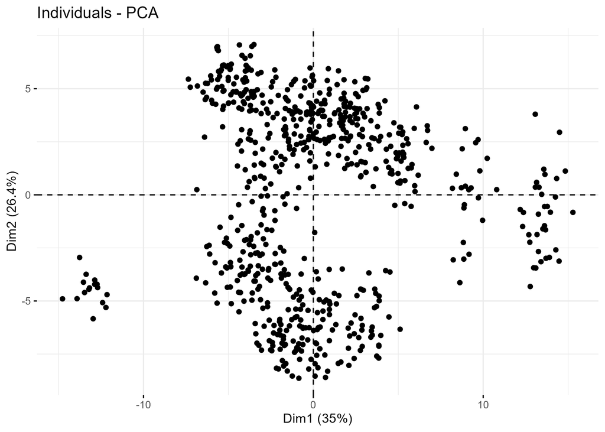

```r
knitr::include_graphics("../output/PC1vsPC2.png")
```

## 3.2 2. How many observations are there in each cluster?

The number of observations in each cluster is given in the following table:

```r
weather %>%
  mutate(cluster = mod_km5$cluster) %>% #to create a column with cluster id
  dplyr::select(year, site, cluster) %>%
  group_by(cluster) %>%
  tally() #To get the length of each of the cluster
```

```
# A tibble: 5 × 2
  cluster     n
    <int> <int>
1       1   208
2       2   182
3       3    16
4       4   236
5       5    56
```

## 3.3 3. Using the `fviz_cluster()` function, import here the original plot with k=4 did in class, and the new one with the number of k you selected for this exercise. How do they visually compare? Which one seems to be a better choice, and why?

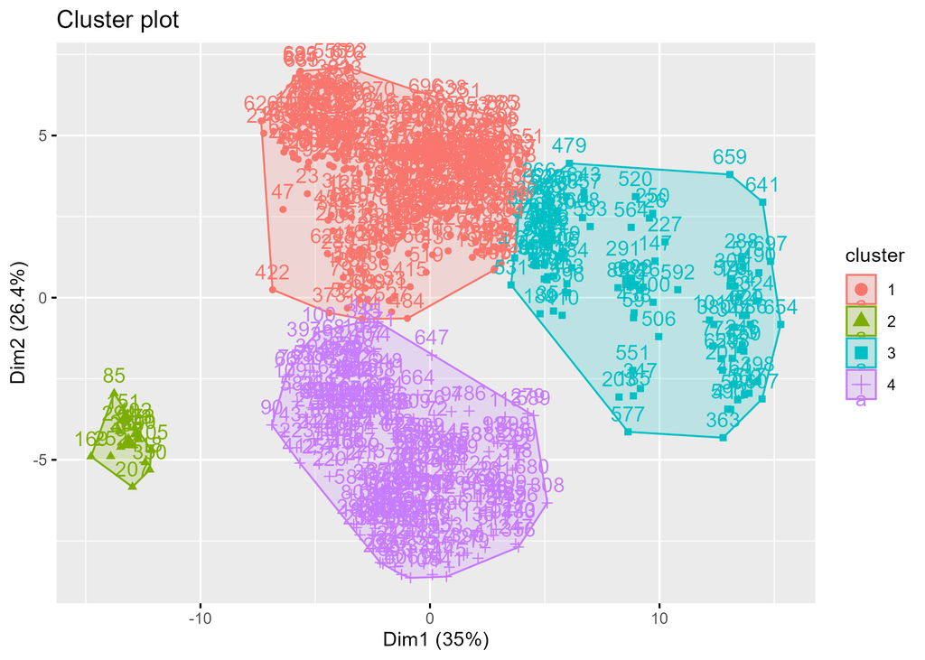

```r
knitr::include_graphics("../output/clustervalidation_class.png")
```

The original cluster plot with k = 4 as created in class is shown above.

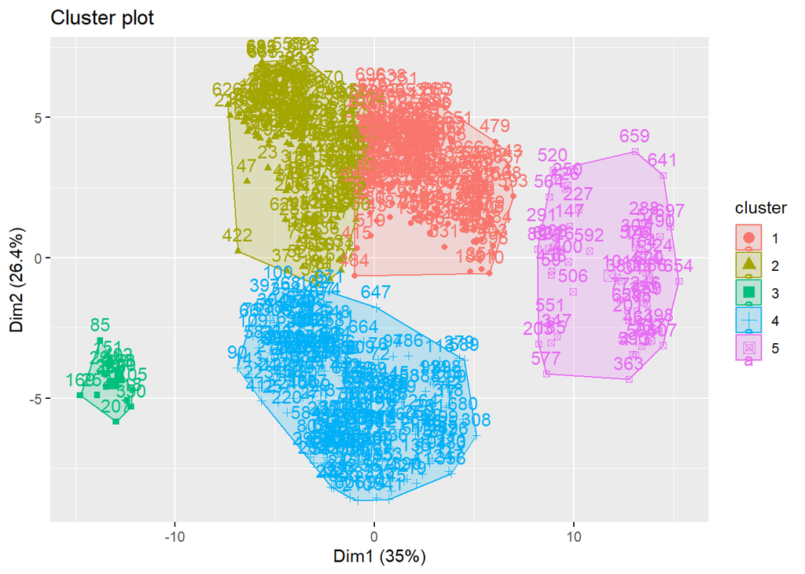

```r
fviz_cluster(mod_km5,
             data = weather_norm
             )
```

```r
ggsave("../output/clustervalidation_assignment.png",
       width = 7,
       height = 5)
```

The newly-created cluster plot with k = 5 for this assignment is shown above.

In terms of visual comparison, the cluster plot created in the class has 4 distinct clusters whereas the newly-created cluster plot in this assignment has 5 clusters. Also, it appears that there is no cluster overlapping one another in the cluster plot with 4 clusters created in the class, whereas at least two clusters are overlapping in the cluster plot with 5 clusters created in this assignment.

It seems to me that choosing 4 clusters instead of 5 is a better choice because we are able to avoid overlapping of clusters when the number of cluster are selected as 4 (k = 4) instead of 5.

# 4 Submitting your work

Once you have developed all the code and answers, make sure to Render this quarto file.

**Notes on rendering**:

- Make sure to render your work and inspect how the final html look like.
- If it does not look professional for whatever reason, then fix the issue, re-render it, recheck.
- Only send me your work once your html file looks professional.
  - **DO NOT** delete the file’s heading levels (# and ##). They set up the proper heading 1 and 2 levels, and I use them to guide my grading.
  - If a given chunk is also outputting warnings or messages, inhibit this behavior by changing the chunk options `message` and `warning` to `FALSE` (I’ll demo this in a moment).
  - If, after rendered, 2 lines of text are connected and you wish to “break line” between them, add 2 extra spaces after the first one (I’lld demo this in a moment).

After rendering, an .html file will be created on your `code` folder.

Rename this file to `Assignment-09-kmeans-LASTNAME.html`.

For ex., mine would be `Assignment-09-kmeans-Bastos.html`.

Submit your work by uploading the **html** file to **eLC Assignment #9 - K-means** by April 3rd 11:59 pm.